# Analysis of James et al (2015), Experiment 2

Richard D. Morey (moreyr@cardiff.ac.uk)

8 September 2021

## Load and format data

We load the `dplyr` library for its data science functions, which we will use to load and manipulate the data.

```r
library(dplyr)
```

We load the data using the `read_csv` function in the `readr` package. This lets us specify all the column types (i: integer, d: numeric). We then

1. specify helpful labels for the factors `Condition` and `Time_of_Day`,
2. specify a row number column called `id`, and
3. create the proper missing data in the Tetris variables when a participant did not play Tetris.

We put the neatened data set into a variable called `tetris`.

```r
here::here('data/James_et_al_2015_Exp2.csv') %>%
  readr::read_csv(col_types = 'iiiiddddddddddddiiiiiiiididi') %>%
  mutate(
    Condition = factor(Condition,
                       labels = c(
                         'No-Task Control',
                         'Reactivation+Tetris',
                         'Tetris Only',
                         'Reactivation Only'
                         )
                       ),
    Time_of_Day = factor(Time_of_Day,
                         levels = 1:3,
                         labels = c(
                           'morning',
                           'afternoon',
                           'evening'
                           )
                         ),
    id = factor(row_number()),
    Tetris_Total_Score = case_when(
      grepl(Condition, pattern = 'Tetris') ~ Tetris_Total_Score,
      TRUE ~ NA_integer_
    ),
    Self_Rated_Tetris_Performance = case_when(
      grepl(Condition, pattern = 'Tetris') ~ Self_Rated_Tetris_Performance,
      TRUE ~ NA_real_
    )
  ) -> tetris
```

## Plots and analyses

We will conduct the three analyses corresponding to the three panels in figure 4 of James et al (p. 1210):

1. Figure 4a, memory intrusion counts after the disturbing video but *before* random assignment to the experimental manipulation,
2. Figure 4b, memory intrusions recorded in the participants’ diaries from day 1 to day 7 *after* the experimental manipulation,
3. Figure 4c, memory intrusions during the Intrusion-provocation task on Day 7 (see p. 1204 for details)

We will use the `ggplot2` to create our plots.

```r
library(ggplot2)
```

### Before the experimental manipulation

First, we create a standard bar plot: means with standard errors. We:

1. group the observations by condition,
2. summarise, computing the mean and standard error by condition, then
3. pass the resulting summarised data to `ggplot` for a bar plot.

```r
tetris %>%
  group_by(Condition) %>%
  summarise(
    mean = mean(Day_Zero_Number_of_Intrusions),
    se = sd(Day_Zero_Number_of_Intrusions)/sqrt(n())
  ) %>%
  ggplot(aes(y = mean, x = Condition, color = Condition)) +
  geom_point(size = 4) +
  geom_errorbar(
    aes(ymin = mean - se, ymax = mean + se),
    width = 0, size = 2
  ) +
  labs(
    y = 'Memory intrusions, Day 0',
    title = 'Intrusions before critical manipulation',
    subtitle = 'James et al (2015)',
    caption = 'c.f. James et al (2015), figure 4a (p. 1210)'
  ) +
  ylim(c(0, NA)) +
  theme(legend.position = 'none') -> ggplot_baseline_standard
```

We can print the plot.

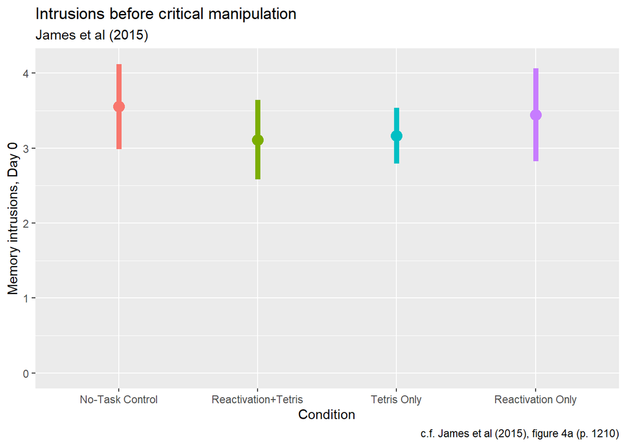

```r
ggplot_baseline_standard
```

We can also save the plot to a file.

```r
ggplot_baseline_standard %>%
  ggsave(
    filename = here::here('figures/baseline_standard.png'),
    width = 7, height = 5, units = 'in', dpi = 300
    )
```

We now create a much better descriptive plot, showing both each data point and a smoothed histogram of each condition. This allows us to see outliers and deviations from our assumptions (such as normality and homogeneity of variance). This code is adapted from https://www.cedricscherer.com/2021/06/06/visualizing-distributions-with-raincloud-plots-and-how-to-create-them-with-ggplot2/.

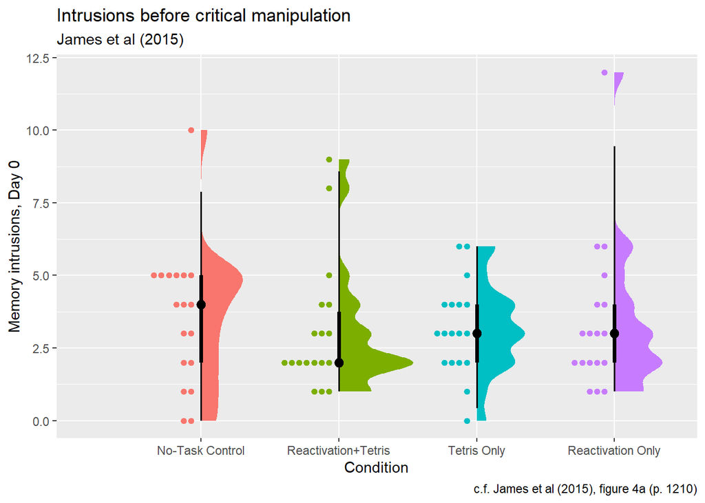

```r
tetris %>%
  ggplot(aes(
    x = Condition,
    y = Day_Zero_Number_of_Intrusions,
    fill = Condition)
  ) +
  ggdist::stat_halfeye(
    adjust = .5,
    width = .6,
    ## set slab interval to show IQR and 95% data range
    .width = c(.5, .95)
  ) +
  ggdist::stat_dots(
    aes(color = Condition),
    side = "left",
    dotsize = .8,
    justification = 1.05,
    binwidth = .3
  ) +
  labs(
    y = 'Memory intrusions, Day 0',
    title = 'Intrusions before critical manipulation',
    subtitle = 'James et al (2015)',
    caption = 'c.f. James et al (2015), figure 4a (p. 1210)'
  ) +
  theme(legend.position = 'none') -> ggplot_baseline_nice

ggplot_baseline_nice
```

```r
ggplot_baseline_nice %>%
  ggsave(
    filename = here::here('figures/baseline_nice.png'),
    width = 7, height = 5, units = 'in', dpi = 300
  )
```

As another way of assessing the normality assumption, we can perform a Shapiro-Wilks test on each condition. We

1. split the data by condition using `split`, then
2. use `map` to compute the test for each condition separately.

```r
tetris %>%
  split(.$Condition) %>%
  purrr::map(
    ~ .$Day_Zero_Number_of_Intrusions %>%
      shapiro.test(.)
  )
```

```
## $`No-Task Control`
##
##  Shapiro-Wilk normality test
##
## data:  .
## W = 0.89685, p-value = 0.05065
##
##
## $`Reactivation+Tetris`
##
##  Shapiro-Wilk normality test
##
## data:  .
## W = 0.78069, p-value = 0.0008209
##
##
## $`Tetris Only`
##
##  Shapiro-Wilk normality test
##
## data:  .
## W = 0.95483, p-value = 0.5057
##
##
## $`Reactivation Only`
##
##  Shapiro-Wilk normality test
##
## data:  .
## W = 0.77389, p-value = 0.0006648
```

We now perform a one-way ANOVA using the `ez` package and put the result into a variable called `ez_obj_baseline` (baseline because this ANOVA is before randomization to experimental condition).

```r
tetris %>%
  ez::ezANOVA(dv = Day_Zero_Number_of_Intrusions,
              wid = id,
              between = Condition,
              detailed = TRUE
  ) -> ez_obj_baseline
```

```
## Coefficient covariances computed by hccm()
```

We print the ANOVA, which will also (helpfully) contain a Levene’s test for homogeneity of variance.

```r
ez_obj_baseline
```

```
## $ANOVA
##      Effect DFn DFd      SSn      SSd         F         p p<.05         ges
## 1 Condition   3  68 2.486111 345.1667 0.1632598 0.9207355       0.007151133
##
## $`Levene's Test for Homogeneity of Variance`
##   DFn DFd      SSn      SSd         F         p p<.05
## 1   3  68 3.930556 206.0556 0.4323717 0.7304931
```

### After the experimental manipulation (Days 1-7)

We now perform all the above steps, but on the memory intrusions recorded in participants’ diaries from Days 1-7. I now omit most comments; see above for details.

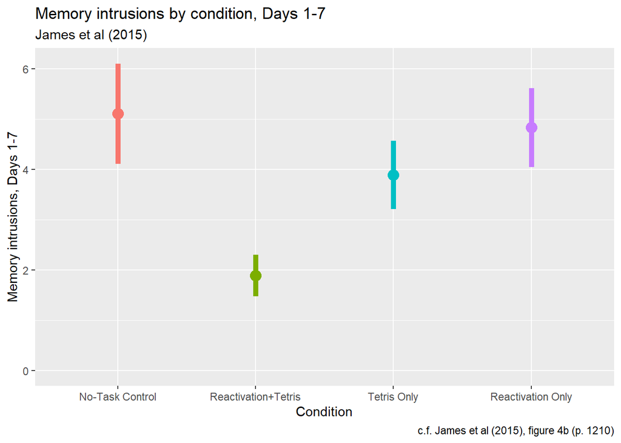

```r
# Standard plot
tetris %>%
  group_by(Condition) %>%
  summarise(
    mean = mean(Days_One_to_Seven_Number_of_Intrusions),
    se = sd(Days_One_to_Seven_Number_of_Intrusions)/sqrt(n())
  ) %>%
  ggplot(aes(y = mean, x = Condition, color = Condition)) +
  geom_point(size = 4) +
  geom_errorbar(
    aes(ymin = mean - se, ymax = mean + se),
    width = 0, size = 2
    ) +
  labs(
    y = 'Memory intrusions, Days 1-7',
    title = 'Memory intrusions by condition, Days 1-7',
    subtitle = 'James et al (2015)',
    caption = 'c.f. James et al (2015), figure 4b (p. 1210)'
  ) +
  ylim(c(0, NA)) +
  theme(legend.position = 'none') -> ggplot_expt_standard

ggplot_expt_standard
```

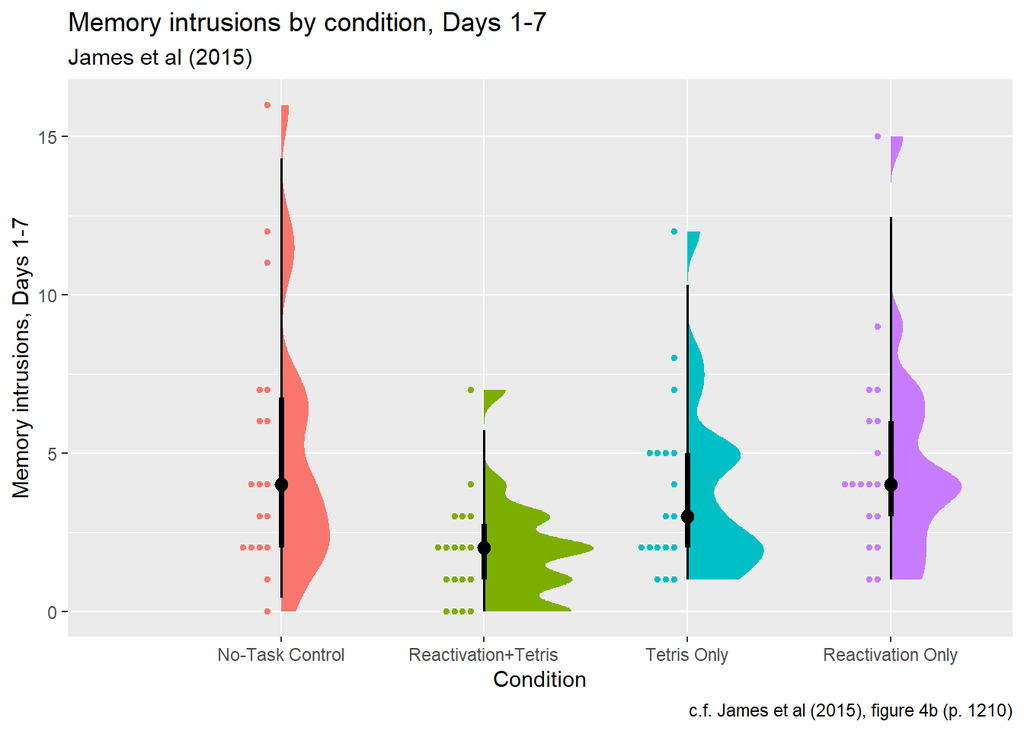

```r
ggplot_expt_standard %>%
  ggsave(
    filename = here::here('figures/expt_standard.png'),
    width = 7, height = 5, units = 'in', dpi = 300
  )


# Good descriptive plot
tetris %>%
  ggplot(aes(
    x = Condition,
    y = Days_One_to_Seven_Number_of_Intrusions,
    fill = Condition)
    ) +
  ggdist::stat_halfeye(
    adjust = .5,
    width = .6,
    ## set slab interval to show IQR and 95% data range
    .width = c(.5, .95)
  ) +
  ggdist::stat_dots(
    aes(color = Condition),
    side = "left",
    dotsize = .8,
    justification = 1.05,
    binwidth = .3
  ) +
  labs(
    y = 'Memory intrusions, Days 1-7',
    title = 'Memory intrusions by condition, Days 1-7',
    subtitle = 'James et al (2015)',
    caption = 'c.f. James et al (2015), figure 4b (p. 1210)'
       ) +
  theme(legend.position = 'none') -> ggplot_expt_nice

ggplot_expt_nice
```

```r
ggplot_expt_nice %>%
  ggsave(
    filename = here::here('figures/expt_nice.png'),
    width = 7, height = 5, units = 'in', dpi = 300
  )

tetris %>%
  split(.$Condition) %>%
  purrr::map(
    ~ .$Days_One_to_Seven_Number_of_Intrusions %>%
      shapiro.test(.)
  )
```

```
## $`No-Task Control`
##
##  Shapiro-Wilk normality test
##
## data:  .
## W = 0.87235, p-value = 0.01946
##
##
## $`Reactivation+Tetris`
##
##  Shapiro-Wilk normality test
##
## data:  .
## W = 0.85802, p-value = 0.01136
##
##
## $`Tetris Only`
##
##  Shapiro-Wilk normality test
##
## data:  .
## W = 0.84978, p-value = 0.008401
##
##
## $`Reactivation Only`
##
##  Shapiro-Wilk normality test
##
## data:  .
## W = 0.84912, p-value = 0.008202
```

```r
tetris %>%
  ez::ezANOVA(dv = Days_One_to_Seven_Number_of_Intrusions,
              wid = id,
              between = Condition,
              return_aov = TRUE,
              detailed = TRUE
  ) -> ez_obj_expt
```

```
## Coefficient covariances computed by hccm()
```

We print the object, which now contains three (rather than two) list elements:

- `ANOVA`: the ANOVA we expect,
- `Levene's Test for Homogeneity of Variance`: Levene’s test, and
- `aov`: another analysis of variance object. We requested this above with `return_aov=TRUE`. We’ll need the extra information in it to compute *post hoc* analyses.

```r
ez_obj_expt
```

```
## $ANOVA
##      Effect DFn DFd      SSn      SSd        F          p p<.05       ges
## 1 Condition   3  68 114.8194 685.8333 3.794762 0.01408578     * 0.1434073
##
## $`Levene's Test for Homogeneity of Variance`
##   DFn DFd      SSn      SSd        F         p p<.05
## 1   3  68 28.48611 381.3889 1.692984 0.1767091
##
## $aov
## Call:
##    aov(formula = formula(aov_formula), data = data)
##
## Terms:
##                 Condition Residuals
## Sum of Squares   114.8194  685.8333
## Deg. of Freedom         3        68
##
## Residual standard error: 3.175812
## Estimated effects may be unbalanced
```

Of course, we also probably want to look at a *post hoc* analysis. We can use the `TukeyHSD` function to compute Tukey *post hoc* intervals and *p* values for the differences between all conditions.

```r
TukeyHSD(ez_obj_expt$aov)
```

```
##   Tukey multiple comparisons of means
##     95% family-wise confidence level
##
## Fit: aov(formula = formula(aov_formula), data = data)
##
## $Condition
##                                             diff        lwr        upr
## Reactivation+Tetris-No-Task Control   -3.2222222 -6.0102860 -0.4341584
## Tetris Only-No-Task Control           -1.2222222 -4.0102860  1.5658416
## Reactivation Only-No-Task Control     -0.2777778 -3.0658416  2.5102860
## Tetris Only-Reactivation+Tetris        2.0000000 -0.7880638  4.7880638
## Reactivation Only-Reactivation+Tetris  2.9444444  0.1563806  5.7325083
## Reactivation Only-Tetris Only          0.9444444 -1.8436194  3.7325083
##                                           p adj
## Reactivation+Tetris-No-Task Control   0.0170843
## Tetris Only-No-Task Control           0.6572614
## Reactivation Only-No-Task Control     0.9936134
## Tetris Only-Reactivation+Tetris       0.2422598
## Reactivation Only-Reactivation+Tetris 0.0344808
## Reactivation Only-Tetris Only         0.8089270
```

### Day 7 Provocation Task Intrusions

We now perform all the above steps, but on the memory intrusions recorded in intrusion provocation task in the lab on day 7. I now omit most comments; see above for details.

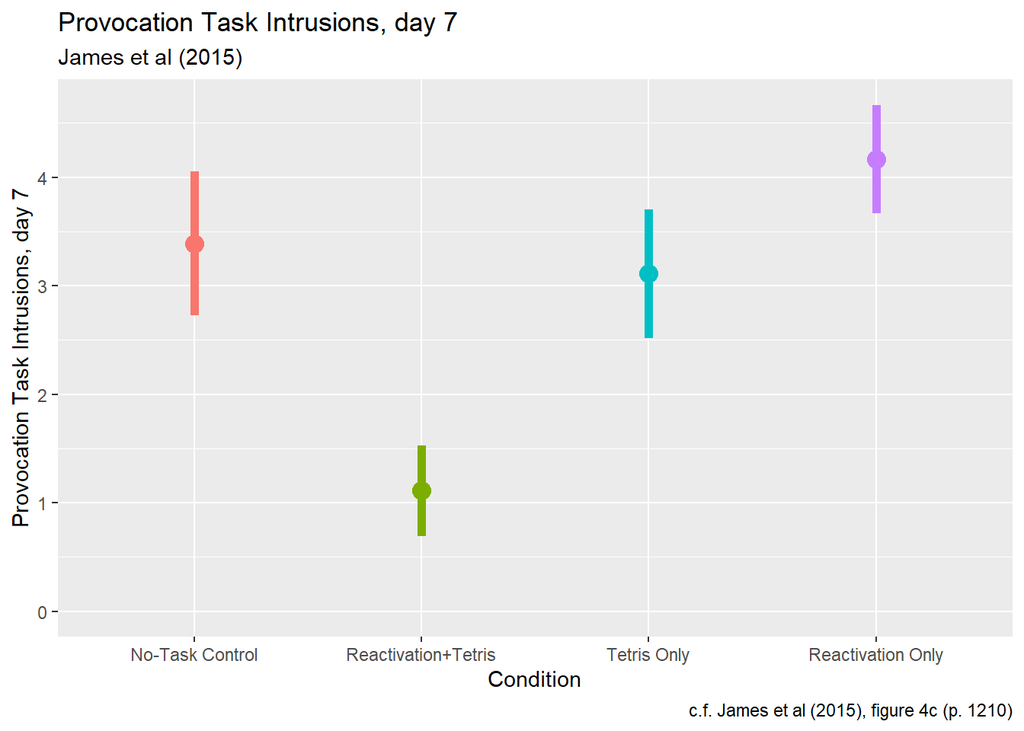

```r
# Standard plot
tetris %>%
  group_by(Condition) %>%
  summarise(
    mean = mean(Number_of_Provocation_Task_Intrusions),
    se = sd(Number_of_Provocation_Task_Intrusions)/sqrt(n())
  ) %>%
  ggplot(aes(y = mean, x = Condition, color = Condition)) +
  geom_point(size = 4) +
  geom_errorbar(
    aes(ymin = mean - se, ymax = mean + se),
    width = 0, size = 2
  ) +
  labs(
    y = 'Provocation Task Intrusions, day 7',
    title = 'Provocation Task Intrusions, day 7',
    subtitle = 'James et al (2015)',
    caption = 'c.f. James et al (2015), figure 4c (p. 1210)'
  ) +
  ylim(c(0, NA)) +
  theme(legend.position = 'none') -> ggplot_ipt7_standard

ggplot_ipt7_standard
```

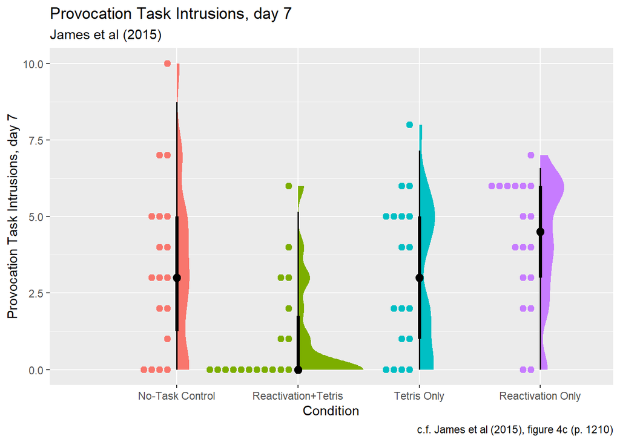

```r
ggplot_ipt7_standard %>%
  ggsave(
    filename = here::here('figures/ipt7_standard.png'),
    width = 7, height = 5, units = 'in', dpi = 300
  )


# Good descriptive plot
tetris %>%
  ggplot(aes(
    x = Condition,
    y = Number_of_Provocation_Task_Intrusions,
    fill = Condition)
  ) +
  ggdist::stat_halfeye(
    adjust = .5,
    width = .6,
    ## set slab interval to show IQR and 95% data range
    .width = c(.5, .95)
  ) +
  ggdist::stat_dots(
    aes(color = Condition),
    side = "left",
    dotsize = .8,
    justification = 1.05,
    binwidth = .3
  ) +
  labs(
    y = 'Provocation Task Intrusions, day 7',
    title = 'Provocation Task Intrusions, day 7',
    subtitle = 'James et al (2015)',
    caption = 'c.f. James et al (2015), figure 4c (p. 1210)'
  ) +
  theme(legend.position = 'none') -> ggplot_ipt7_nice

ggplot_ipt7_nice
```

```r
ggplot_ipt7_nice %>%
  ggsave(
    filename = here::here('figures/ipt7_nice.png'),
    width = 7, height = 5, units = 'in', dpi = 300
  )

tetris %>%
  split(.$Condition) %>%
  purrr::map(
    ~ .$Number_of_Provocation_Task_Intrusions %>%
      shapiro.test(.)
  )
```

```
## $`No-Task Control`
##
##  Shapiro-Wilk normality test
##
## data:  .
## W = 0.92965, p-value = 0.1914
##
##
## $`Reactivation+Tetris`
##
##  Shapiro-Wilk normality test
##
## data:  .
## W = 0.69809, p-value = 7.588e-05
##
##
## $`Tetris Only`
##
##  Shapiro-Wilk normality test
##
## data:  .
## W = 0.90969, p-value = 0.08495
##
##
## $`Reactivation Only`
##
##  Shapiro-Wilk normality test
##
## data:  .
## W = 0.89467, p-value = 0.04644
```

```r
tetris %>%
  ez::ezANOVA(dv = Number_of_Provocation_Task_Intrusions,
              wid = id,
              between = Condition,
              return_aov = TRUE,
              detailed = TRUE
  ) -> ez_obj_ipt7
```

```
## Coefficient covariances computed by hccm()
```

```r
ez_obj_ipt7
```

```
## $ANOVA
##      Effect DFn DFd      SSn      SSd        F           p p<.05      ges
## 1 Condition   3  68 91.44444 372.3333 5.566895 0.001781928     * 0.197173
##
## $`Levene's Test for Homogeneity of Variance`
##   DFn DFd      SSn   SSd        F        p p<.05
## 1   3  68 14.27778 150.5 2.150363 0.101924
##
## $aov
## Call:
##    aov(formula = formula(aov_formula), data = data)
##
## Terms:
##                 Condition Residuals
## Sum of Squares    91.4444  372.3333
## Deg. of Freedom         3        68
##
## Residual standard error: 2.339977
## Estimated effects may be unbalanced
```

```r
TukeyHSD(ez_obj_ipt7$aov)
```

```
##   Tukey multiple comparisons of means
##     95% family-wise confidence level
##
## Fit: aov(formula = formula(aov_formula), data = data)
##
## $Condition
##                                             diff         lwr       upr
## Reactivation+Tetris-No-Task Control   -2.2777778 -4.33205653 -0.223499
## Tetris Only-No-Task Control           -0.2777778 -2.33205653  1.776501
## Reactivation Only-No-Task Control      0.7777778 -1.27650097  2.832057
## Tetris Only-Reactivation+Tetris        2.0000000 -0.05427875  4.054279
## Reactivation Only-Reactivation+Tetris  3.0555556  1.00127681  5.109834
## Reactivation Only-Tetris Only          1.0555556 -0.99872319  3.109834
##                                           p adj
## Reactivation+Tetris-No-Task Control   0.0239364
## Tetris Only-No-Task Control           0.9843888
## Reactivation Only-No-Task Control     0.7515163
## Tetris Only-Reactivation+Tetris       0.0591951
## Reactivation Only-Reactivation+Tetris 0.0011796
## Reactivation Only-Tetris Only         0.5327297
```